# Final Project Stage 2

Yiyi Yuan

**Yiyi’s part**

0. Describe the data and your research question. Where does it come from? How was it collected? What do you hope to learn?
1. athlete_events.csv

The file athlete_events.csv contains 271116 rows and 15 columns;

Each row corresponds to an individual athlete competing in an individual Olympic event (athlete-events). The columns are the following:

ID - Unique number for each athlete; Name - Athlete’s name; Sex - M or F; Age - Integer; Height - In centimeters; Weight - In kilograms; Team - Team name; NOC - National Olympic Committee 3-letter code; Games - Year and season; Year - Integer; Season - Summer or Winter; City - Host city; Sport - Sport; Event - Event; Medal - Gold, Silver, Bronze, or NA.

2. noc_regions.csv

NOC; region; notes;

3. The data was collected from [HERE] (www.sports-reference.com). “The dataset is the result of an incredible amount of research by a group of Olympic history enthusiasts and self-proclaimed ‘statisticians’ [HERE IS THEIR BLOG] (http://olympstats.com)”
4. What we hope to learn:

This dataset provides an opportunity to ask questions about how the Olympics have evolved over time

Our TENTATIVE research question : research on how the Olympics, in all aspects, have evolved over time. For example, how does the participation and performance of women of different sports and event changed over decades, the ranks and overall performance of different nations, etc. We would also (possibly) predit the models and discover relationships between variables.

**Art Competitions From 1912 to 1948**

Some graphs with concise interpretations (by Carrie and Yiyi)

The two graphs below shows the relationship between age and medal categories for olympic competitors. We can see from the graph that bronze, gold and silver medal winners, along with other participants without medals all have relatively similar ages as the bars overlap in their heights and the median are all kept around 25. The IQR for all three medals are all relatively same. Thus there is no huge impact of age to the medal level. Competitors without medal has a higher range of age (about 100) than medal winners. Gold medal winners have the smallest range of age. All three medal winners’ and other participants’ ages are pretty right skewed. It’s interesting to see that there are quite a lot of people over 75 participating in olympic, without winning any medals. Those won the medals are all under 75 years old.

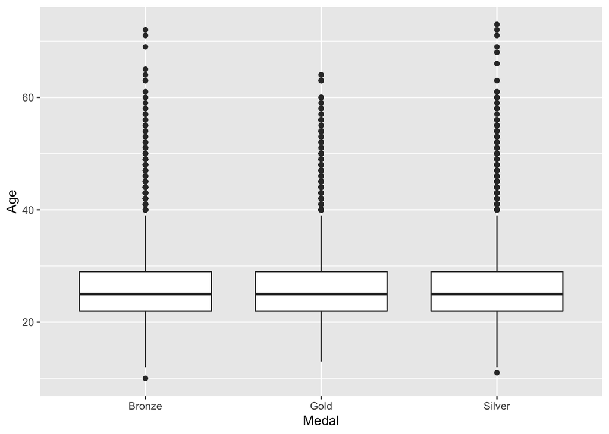

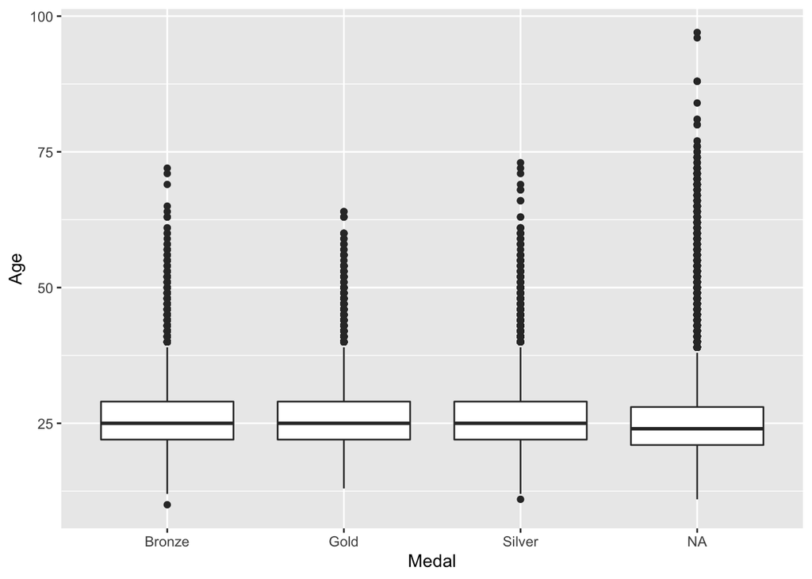

The graph shows the relationship between sex and age for olympic competitors. We can see from the graph that males olympic competitors have higher age median, but both males and females have relatively similar ages as their boxes overlap. What’s more interesting in this graph is that males tend to have higher age range (about 100) than women (about 75). Both ages for are right skewed.

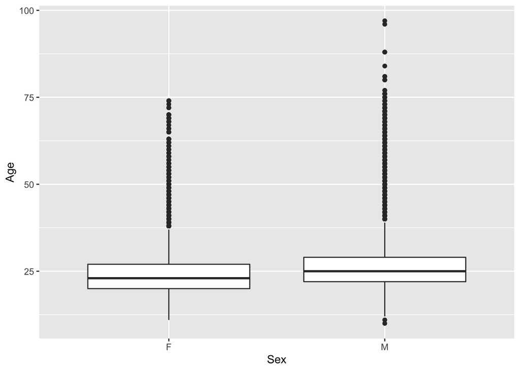

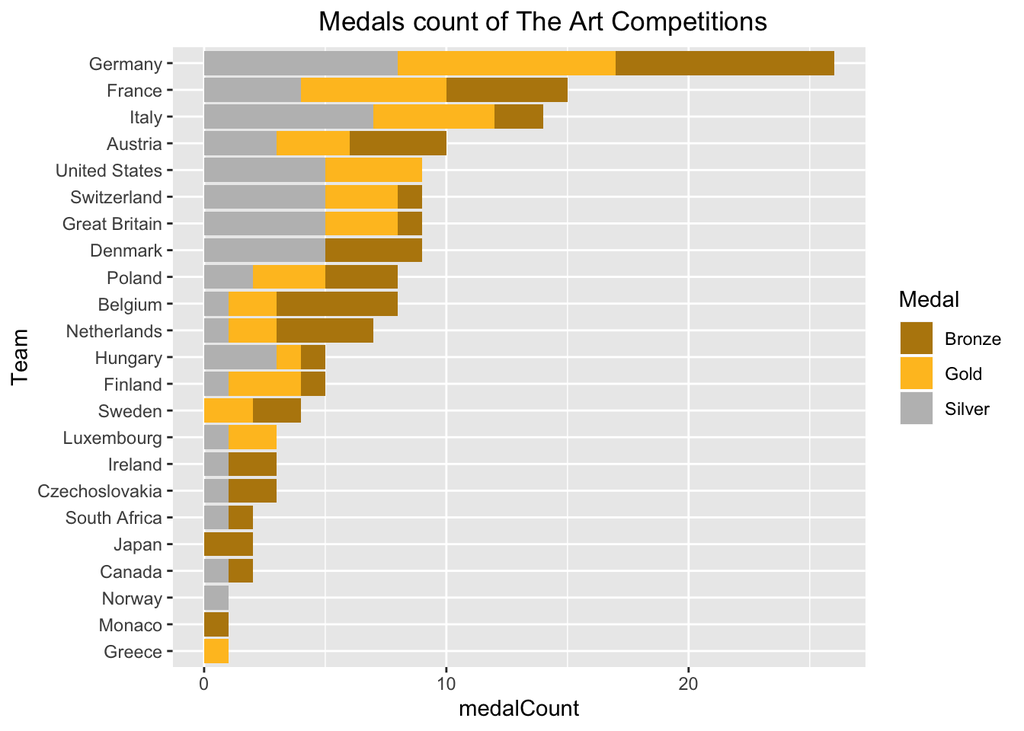

Among 50 nations, Germany won the most medals in the Art Competitions (between 1912 and 1948) Over 1/3 of medals were awarded to artists from Germany, France, Italy, and Austria.

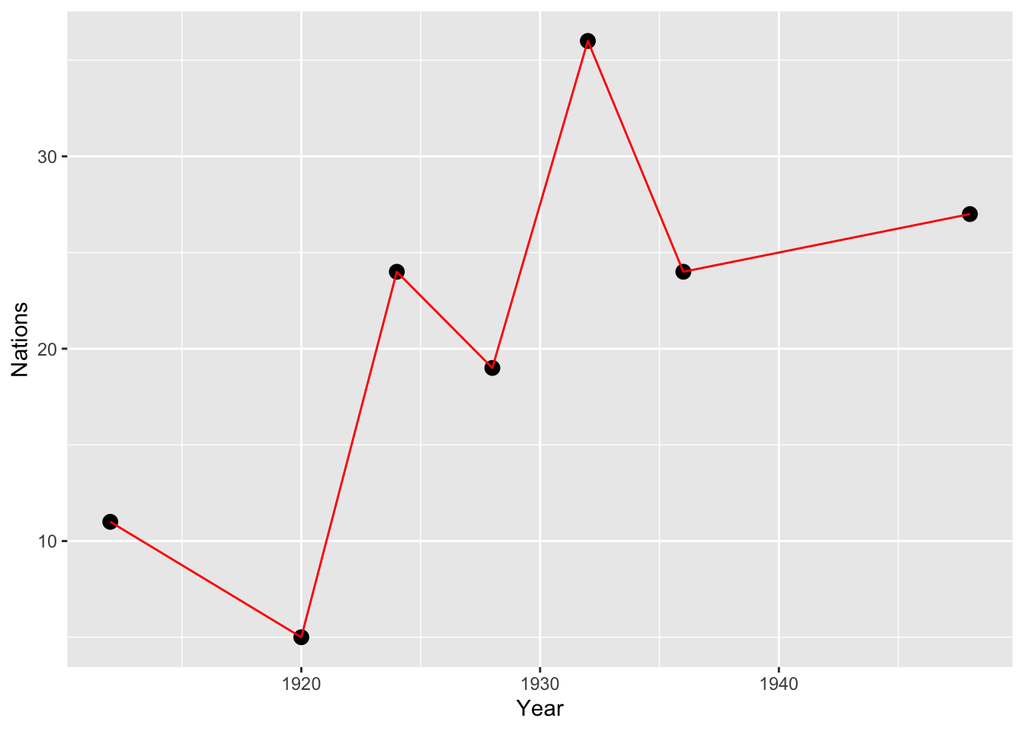

```r
# https://rpubs.com/dgrtwo/length_unique_vs_n_distinct
artTeam <- artCompetitorData %>% filter(Team != "Unknown") %>%
  group_by(Year) %>%
 summarize(
    Events = n_distinct(Event),
    Nations = n_distinct(Team),
    Artists = n_distinct(unique(Name))
  )

ggplot(artTeam, aes(x = Year, y = Nations)) +
  geom_point(size = 3) +
  geom_line(color = "red") +
  xlab("Year")
```

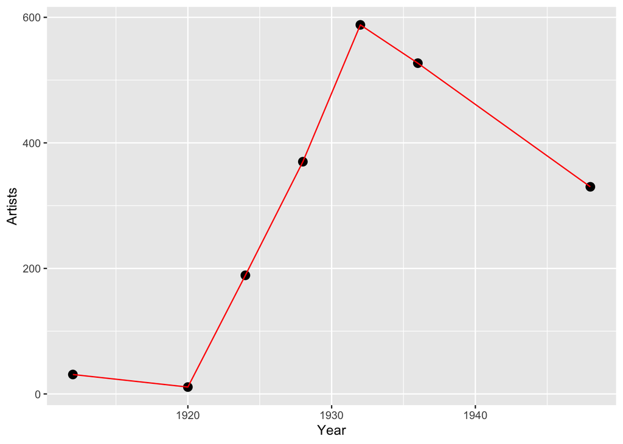

```r
ggplot(artTeam, aes(x = Year, y = Artists)) +
  geom_point(size = 3) +
  geom_line(color = "red") +
  xlab("Year")
```

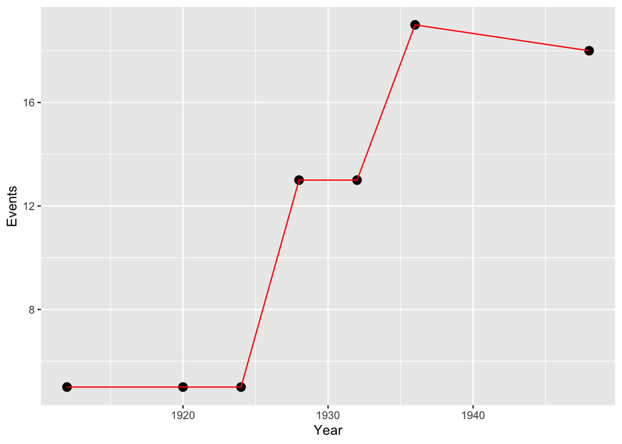

```r
ggplot(artTeam, aes(x = Year, y = Events)) +
  geom_point(size = 3) +
  geom_line(color = "red") +
  xlab("Year")
```

Apparently, nations participated, and events held increased and then decreased over time. Nations participated and artists grew hugely from 1920 to 1932, with the events that was held during that period of time boosted correspondingly.

2.categorial: sport

```r
Lm.weight <- lm(Weight ~ Age, data = data)
tidy(Lm.weight)
```

```
## # A tibble: 2 x 5
##   term        estimate std.error statistic p.value
##   <chr>          <dbl>     <dbl>     <dbl>   <dbl>
## 1 (Intercept)   56.8     0.144       394.        0
## 2 Age            0.555   0.00561      98.8       0
```

```r
set.seed(543)

Weight_Age <-
  data %>%
  rep_sample_n(size = 300, replace = FALSE, reps = 300) %>%
  group_by(replicate) %>%
  mutate(new_Weight = sample(Weight)) %>%
  do(lm(new_Weight ~ Age, data = .) %>% tidy())
```

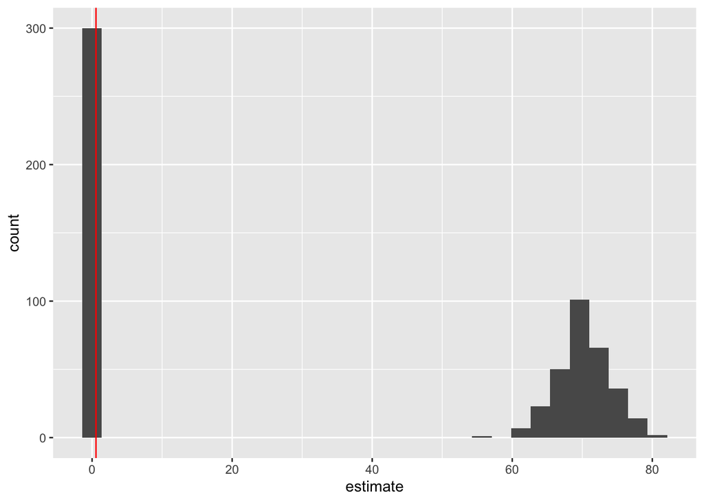

```r
Weight_Age %>%
  ggplot(aes(x = estimate)) +
  geom_histogram(bins = 30) +
  geom_vline(xintercept = 0.5546711, color = "red")
```

```r
Lm.Height <- lm(Height ~ Age, data = data)
tidy(Lm.Height)
```

```
## # A tibble: 2 x 5
##   term        estimate std.error statistic p.value
##   <chr>          <dbl>     <dbl>     <dbl>   <dbl>
## 1 (Intercept)  169.      0.106      1598.        0
## 2 Age            0.263   0.00411      64.0       0
```

```r
set.seed(543)

Height_Age <-
  data %>%
  rep_sample_n(size = 300, replace = FALSE, reps = 300) %>%
  group_by(replicate) %>%
  mutate(new_Height = sample(Height)) %>%
  do(lm(new_Height ~ Age, data=.) %>% tidy())
```

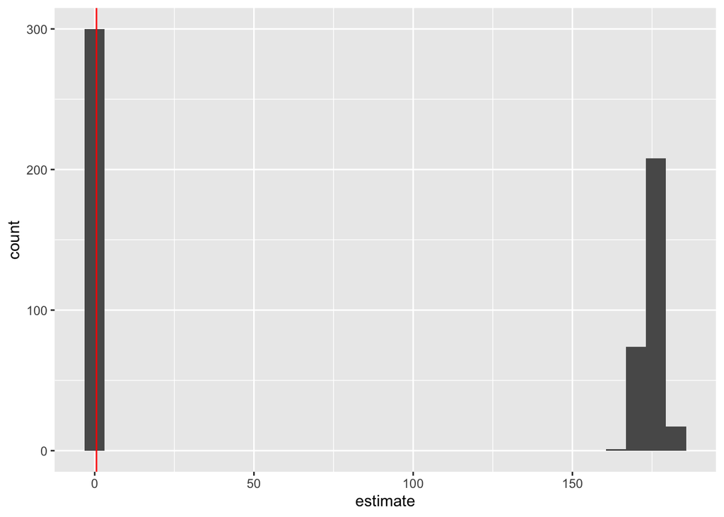

```r
Height_Age %>%
  ggplot(aes(x = estimate)) +
  geom_histogram(bins = 30) +
  geom_vline(xintercept = 0.5546711, color = "red")
```

```r
Lm.HW <- lm(Height ~ Weight, data = data)
tidy(Lm.HW)
```

```
## # A tibble: 2 x 5
##   term        estimate std.error statistic p.value
##   <chr>          <dbl>     <dbl>     <dbl>   <dbl>
## 1 (Intercept)  134.     0.0706       1898.       0
## 2 Weight         0.586  0.000979      599.       0
```

```r
set.seed(543)

Weight_Height <-
  data %>%
  rep_sample_n(size = 300, replace = FALSE, reps = 300) %>%
  group_by(replicate) %>%
  mutate(new_Height = sample(Height)) %>%
  do(lm(Height ~ Weight, data=.) %>% tidy())
```

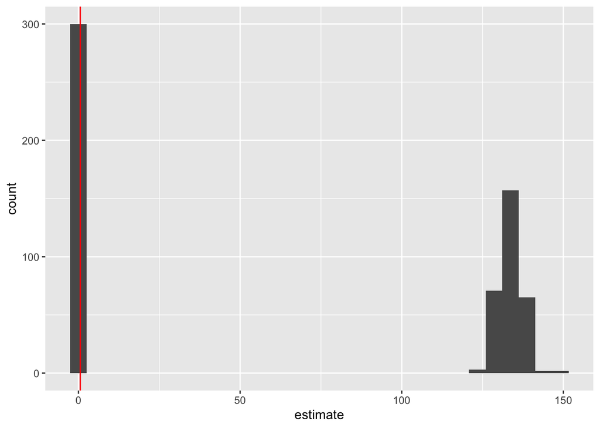

```r
Weight_Height %>%
  ggplot(aes(x = estimate)) +
  geom_histogram(bins = 30) +
  geom_vline(xintercept = 0.5546711, color = "red")
```